# Импорты

```python
import pandas as pd
import scipy.stats as st
import numpy as np
import matplotlib.pyplot as plt
import seaborn as sns
import statsmodels.api as sm
import scipy
```

# Обзор датасета

Датасете собрана статистика о баскетбольных матчах по сезонам, с 1999г по 2020г.

Данные

- Season - Сезон YYYY-YYYY
- Player - Имя игрока
- 3PM - сколько сделано трехочковых
- height_cm - Рост игрока

```python
df = pd.read_csv("/content/players.csv")[["Season", "Player","3PM", "height_cm"]]
df.head()
```

|  | Season | Player | 3PM | height_cm |
| --- | --- | --- | --- | --- |
| 0 | 1999 - 2000 | Shaquille O'Neal | 0 | 216.0 |
| 1 | 1999 - 2000 | Vince Carter | 95 | 198.0 |
| 2 | 1999 - 2000 | Karl Malone | 2 | 206.0 |
| 3 | 1999 - 2000 | Allen Iverson | 89 | 183.0 |
| 4 | 1999 - 2000 | Gary Payton | 177 | 193.0 |

Избавимся от пропусков, просто удалив их

```python
df.shape
```

```
(53949, 4)
```

```python
df.dropna(inplace=True)
df.shape
```

```
(53875, 4)
```

Итого, мы имеем две метрики:

- 3PM - сколько сделано трехочковых (Дискретная)
- height - Рост игрока (Непрерывная)

Для каждого периода сравним распределение метрик

```python
df["Season"] = df["Season"].str.slice(stop=4).astype(int)
```

```python
df["Season"].unique()
```

```
array([1999, 2000, 2001, 2002, 2003, 2004, 2005, 2006, 2007, 2008, 2009,
       2010, 2011, 2012, 2013, 2014, 2015, 2016, 2017, 2018, 2019])
```

```python
periods = [
    df[df['Season'] == year][["3PM", "height_cm"]]
    for year in range(1999, 2020)]
```

```python
print("Первый период, год 1999")
periods[0]
```

```
Первый период, год 1999
```

|  | 3PM | height_cm |
| --- | --- | --- |
| 0 | 0 | 216.0 |
| 1 | 95 | 198.0 |
| 2 | 2 | 206.0 |
| 3 | 89 | 183.0 |
| 4 | 177 | 193.0 |
| ... | ... | ... |
| 337 | 0 | 211.0 |
| 338 | 3 | 160.0 |
| 339 | 0 | 206.0 |
| 340 | 2 | 193.0 |
| 341 | 3 | 198.0 |

342 rows × 2 columns

# Непрерывное распределение. Рост игроков

## Критерий Колмогорова-Смирнова

Проверим, что с годами распределение роста игроков не изменялось

```python
for year in range(2000, 2020):
    p_value = st.ks_2samp(periods[year - 1999 - 1]["height_cm"],
                          periods[year - 1999]["height_cm"]
                          ).pvalue
    if p_value < 0.05:
        print(f"Распределение {year - 1} и {year} годов значимо различается")
```

```
Распределение 2010 и 2011 годов значимо различается
```

Видим, что при попарном сравнении значимо различается только распределение между 2010 и 2011 годами

Проверим однородность распределения роста между самым ранним сезоном 1999 года и остальными

```python
for year in range(2000, 2020):
    p_value = st.ks_2samp(periods[0]["height_cm"],
                          periods[year - 1999]["height_cm"]
                          ).pvalue
    if p_value < 0.05:
        print(f"Распределение {1999} и {year} годов значимо различается")
```

```
Распределение 1999 и 2003 годов значимо различается
Распределение 1999 и 2004 годов значимо различается
Распределение 1999 и 2005 годов значимо различается
Распределение 1999 и 2006 годов значимо различается
Распределение 1999 и 2007 годов значимо различается
Распределение 1999 и 2008 годов значимо различается
Распределение 1999 и 2009 годов значимо различается
Распределение 1999 и 2010 годов значимо различается
Распределение 1999 и 2011 годов значимо различается
Распределение 1999 и 2012 годов значимо различается
Распределение 1999 и 2013 годов значимо различается
Распределение 1999 и 2014 годов значимо различается
Распределение 1999 и 2015 годов значимо различается
Распределение 1999 и 2016 годов значимо различается
Распределение 1999 и 2017 годов значимо различается
Распределение 1999 и 2018 годов значимо различается
Распределение 1999 и 2019 годов значимо различается
```

Видим, что начиная с 2003 года, распределение роста значимо отличается от того, что было в 1999-м году

Проверим однородность распределения роста в более поздний период, скажем с 2015 года.

```python
for year in range(2016, 2020):
    p_value = st.ks_2samp(periods[2015 - 1999]["height_cm"],
                          periods[year - 1999]["height_cm"]
                          ).pvalue
    if p_value < 0.05:
        print(f"Распределение {2015} и {year} годов значимо различается")
```

```
Распределение 2015 и 2019 годов значимо различается
```

Видим, что 2015 и 2019 год значимо различаются.

## Расстояние Кульбака-Лейблера

```python
def bins(p, q, n_bins=10):
    breakpoints = np.arange(0, n_bins + 1) / (n_bins) * 100
    breakpoints = np.histogram(p, n_bins)[1]

    p_percents = np.histogram(p, breakpoints)[0] / len(p)
    q_percents = np.histogram(q, breakpoints)[0] / len(q)

    p_percents = np.clip(p_percents, a_min=0.0001, a_max=None)
    q_percents = np.clip(q_percents, a_min=0.0001, a_max=None)

    return p_percents, q_percents
```

```python
def kl(a, b):
    a, b = bins(a, b)

    return np.sum(np.where(a != 0, a * np.log(a / b), 0))
```

```python
for year in range(2000, 2020):
    x = periods[year - 1999 - 1]["height_cm"]
    y = periods[year - 1999]["height_cm"]
    div = kl(x,y).sum()
    print(f"year: {year - 1}, {year}, div: {div}")
```

```
year: 1999, 2000, div: 0.029048212834346856
year: 2000, 2001, div: 0.021381207825434925
year: 2001, 2002, div: 0.02534707921826663
year: 2002, 2003, div: 0.0127237635869111
year: 2003, 2004, div: 0.005086950054479805
year: 2004, 2005, div: 0.011013792093437062
year: 2005, 2006, div: 0.006604891577742819
year: 2006, 2007, div: 0.003034086253769856
year: 2007, 2008, div: 0.005155627436688302
year: 2008, 2009, div: 0.005360790540245124
year: 2009, 2010, div: 0.005868810258826223
year: 2010, 2011, div: 0.022971137190992925
year: 2011, 2012, div: 0.0020020221371001
year: 2012, 2013, div: 0.001902730156424301
year: 2013, 2014, div: 0.0010067858008151254
year: 2014, 2015, div: 0.001958264690036543
year: 2015, 2016, div: 0.002999378927882948
year: 2016, 2017, div: 0.0006922892747240569
year: 2017, 2018, div: 0.001248446819884044
year: 2018, 2019, div: 0.0005988185715571422
```

Видим, что с годами расстояние Кульбака-Лейблера между некоторыми годами достаточно велико, что свидетельствует он изменении распределения выборок со временем

```python
divs = []
for year in range(2000, 2020):
    x = periods[0]["height_cm"]
    y = periods[year - 1999]["height_cm"]
    div = kl(x,y).sum()
    divs.append(div)
    print(f"year: {1999}, {year}, div: {div}")
```

```
year: 1999, 2000, div: 0.029048212834346856
year: 1999, 2001, div: 0.0629012054580541
year: 1999, 2002, div: 0.03413357447457339
year: 1999, 2003, div: 0.04524110458584283
year: 1999, 2004, div: 0.053435437590607385
year: 1999, 2005, div: 0.09061583222817665
year: 1999, 2006, div: 0.07176283501549482
year: 1999, 2007, div: 0.09311265275900783
year: 1999, 2008, div: 0.0744882524386869
year: 1999, 2009, div: 0.11237571633919376
year: 1999, 2010, div: 0.09091096076009005
year: 1999, 2011, div: 0.14552802936806591
year: 1999, 2012, div: 0.14433091209392462
year: 1999, 2013, div: 0.15094694697798863
year: 1999, 2014, div: 0.15869720792858377
year: 1999, 2015, div: 0.16594673611318175
year: 1999, 2016, div: 0.15346732325564022
year: 1999, 2017, div: 0.16367331964320103
year: 1999, 2018, div: 0.17128645934788822
year: 1999, 2019, div: 0.18248980237213377
```

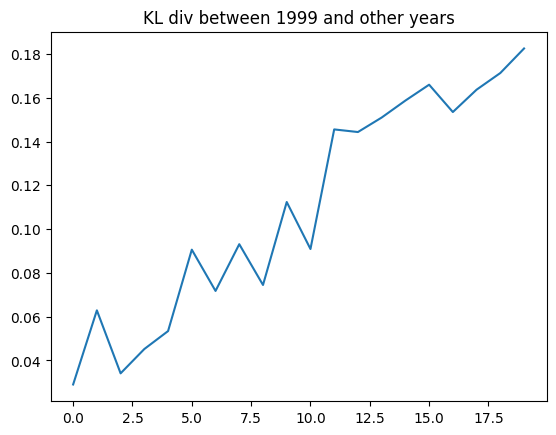

```python
plt.plot(divs)
plt.title("KL div between 1999 and other years")
plt.show()
```

Видим, что расстояние между 1999 годом и остальными годами заметно растет со временем

## Population stability index

```python
def psi(p: np.ndarray, q: np.ndarray):
    return kl(p, q) + kl(q, p)
```

```python
for year in range(2000, 2020):
    value = psi(
        periods[year - 1999]["height_cm"],
        periods[year - 1999 - 1]["height_cm"])
    if value < 0.1:
        print(f"Между {year - 1} и {year} значимых различий нет")
    elif 0.1 <= value < 0.2:
        print("Между {year - 1} и {year} есть тенденции к изменениям, требуется наблюдение")
    else:
        print("Между {year - 1} и {year} значимые изменения")
```

```
Между 1999 и 2000 значимых различий нет
Между 2000 и 2001 значимых различий нет
Между 2001 и 2002 значимых различий нет
Между 2002 и 2003 значимых различий нет
Между 2003 и 2004 значимых различий нет
Между 2004 и 2005 значимых различий нет
Между 2005 и 2006 значимых различий нет
Между 2006 и 2007 значимых различий нет
Между 2007 и 2008 значимых различий нет
Между 2008 и 2009 значимых различий нет
Между 2009 и 2010 значимых различий нет
Между 2010 и 2011 значимых различий нет
Между 2011 и 2012 значимых различий нет
Между 2012 и 2013 значимых различий нет
Между 2013 и 2014 значимых различий нет
Между 2014 и 2015 значимых различий нет
Между 2015 и 2016 значимых различий нет
Между 2016 и 2017 значимых различий нет
Между 2017 и 2018 значимых различий нет
Между 2018 и 2019 значимых различий нет
```

PSI показывается, что значимых различий в годах нет, проверим, есть ли различия между распределением в 1999 году и остальных

```python
for year in range(2000, 2020):
    value = psi(
        periods[0]["height_cm"],
        periods[year - 1999 - 1]["height_cm"])
    if value < 0.1:
        print(f"Между {1999} и {year} значимых различий нет")
    elif 0.1 <= value < 0.2:
        print(f"Между {1999} и {year} есть тенденции к изменениям, требуется наблюдение")
    else:
        print(f"Между {1999} и {year} значимые изменения")
```

```
Между 1999 и 2000 значимых различий нет
Между 1999 и 2001 значимых различий нет
Между 1999 и 2002 есть тенденции к изменениям, требуется наблюдение
Между 1999 и 2003 значимых различий нет
Между 1999 и 2004 значимых различий нет
Между 1999 и 2005 есть тенденции к изменениям, требуется наблюдение
Между 1999 и 2006 есть тенденции к изменениям, требуется наблюдение
Между 1999 и 2007 есть тенденции к изменениям, требуется наблюдение
Между 1999 и 2008 есть тенденции к изменениям, требуется наблюдение
Между 1999 и 2009 есть тенденции к изменениям, требуется наблюдение
Между 1999 и 2010 значимые изменения
Между 1999 и 2011 значимые изменения
Между 1999 и 2012 значимые изменения
Между 1999 и 2013 значимые изменения
Между 1999 и 2014 значимые изменения
Между 1999 и 2015 значимые изменения
Между 1999 и 2016 значимые изменения
Между 1999 и 2017 значимые изменения
Между 1999 и 2018 значимые изменения
Между 1999 и 2019 значимые изменения
```

Результаты совпадают с предыдущими наблюдениями, рост игроков меняет свое распределение со временем

## Data Quality

Посмотрим на распределение среднего роста игрков

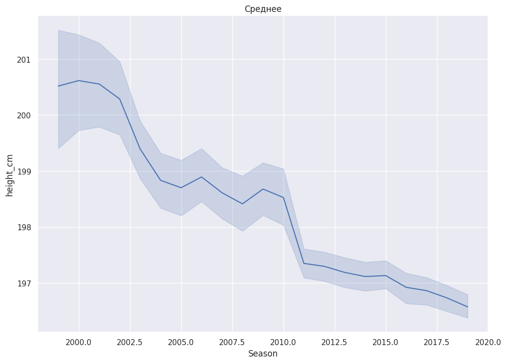

```python
sns.set(rc={'figure.figsize':(11.7,8.27)})
sns.lineplot(data=df, x="Season", y="height_cm").set_title("Среднее")
plt.show()
```

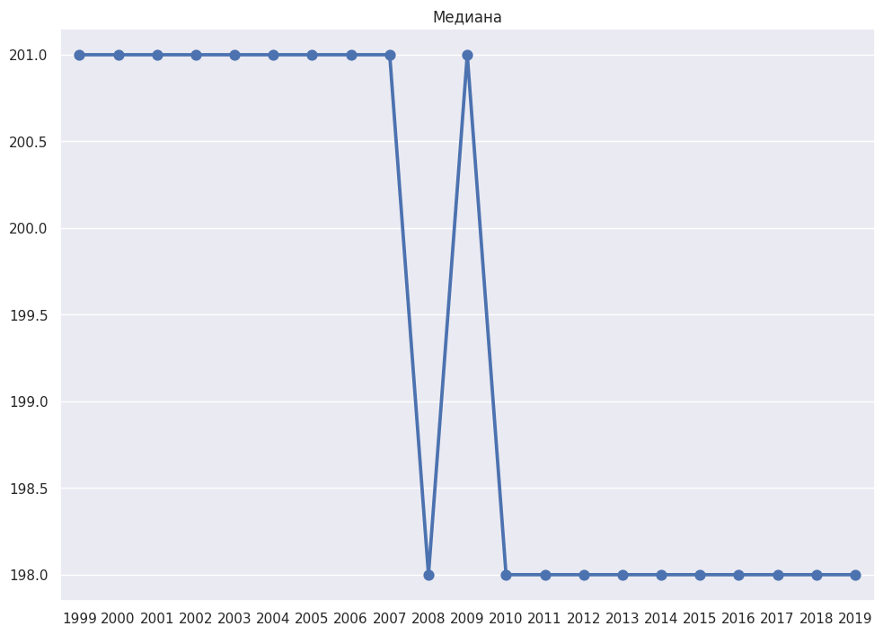

```python
sns.set(rc={'figure.figsize':(11.7,8.27)})
sns.pointplot(x=[i for i in range(1999, 2020)],
              y=[periods[i]["height_cm"].median() for i in range(21)])\
.set_title("Медиана")
plt.show()
```

Видим, что среднее значение роста игроков уменьшалось, может быть, это служило причиной изменения распределений со временем.

Также значение медианы "делится" на два значения - 201 и 198, что тоже свидетельствует о неоднородности распределений

# Дискретное распределение

## Расстояние Кульбака-Лейблера

```python
for year in range(2000, 2020):
    x = periods[year - 1999 - 1]["3PM"]
    y = periods[year - 1999]["3PM"]
    div = kl(x,y).sum()
    print(f"year: {year - 1}, {year}, div: {div}")
```

```
year: 1999, 2000, div: 0.057619909929562826
year: 2000, 2001, div: 0.03386675373343906
year: 2001, 2002, div: 0.04965958594859746
year: 2002, 2003, div: 0.052247981645959174
year: 2003, 2004, div: 0.013123831725370926
year: 2004, 2005, div: 0.020254243824878886
year: 2005, 2006, div: 0.005676932546161872
year: 2006, 2007, div: 0.0202630601344495
year: 2007, 2008, div: 0.002548816328873686
year: 2008, 2009, div: 0.004230567700345162
year: 2009, 2010, div: 0.0021169838592358207
year: 2010, 2011, div: 0.04091783699612025
year: 2011, 2012, div: 0.007334761149670045
year: 2012, 2013, div: 0.004739935301887765
year: 2013, 2014, div: 0.005202809839170682
year: 2014, 2015, div: 0.0016548152327193195
year: 2015, 2016, div: 0.0038175756044677733
year: 2016, 2017, div: 0.0018046335504823833
year: 2017, 2018, div: 0.001624790996495531
year: 2018, 2019, div: 0.10726958460813103
```

Видим, что с годами расстояние Кульбака-Лейблера между некоторыми годами достаточно велико, что свидетельствует он изменении распределения выборок со временем

```python
divs = []
for year in range(2000, 2020):
    x = periods[0]["3PM"]
    y = periods[year - 1999]["3PM"]
    div = kl(x,y).sum()
    divs.append(div)
    print(f"year: {1999}, {year}, div: {div}")
```

```
year: 1999, 2000, div: 0.057619909929562826
year: 1999, 2001, div: 0.06425697353839173
year: 1999, 2002, div: 0.10403927255296208
year: 1999, 2003, div: 0.14217394970679384
year: 1999, 2004, div: 0.14586429290287167
year: 1999, 2005, div: 0.15570420346152816
year: 1999, 2006, div: 0.15440745745473353
year: 1999, 2007, div: 0.14224885855214722
year: 1999, 2008, div: 0.13718289058273425
year: 1999, 2009, div: 0.16503120081734776
year: 1999, 2010, div: 0.13632332100302408
year: 1999, 2011, div: 0.2736425462304969
year: 1999, 2012, div: 0.24499457872716726
year: 1999, 2013, div: 0.2618823406052402
year: 1999, 2014, div: 0.29523369760986107
year: 1999, 2015, div: 0.2547887454722094
year: 1999, 2016, div: 0.27996244085574085
year: 1999, 2017, div: 0.2600535127342157
year: 1999, 2018, div: 0.25800091601395364
year: 1999, 2019, div: 0.2952156234119404
```

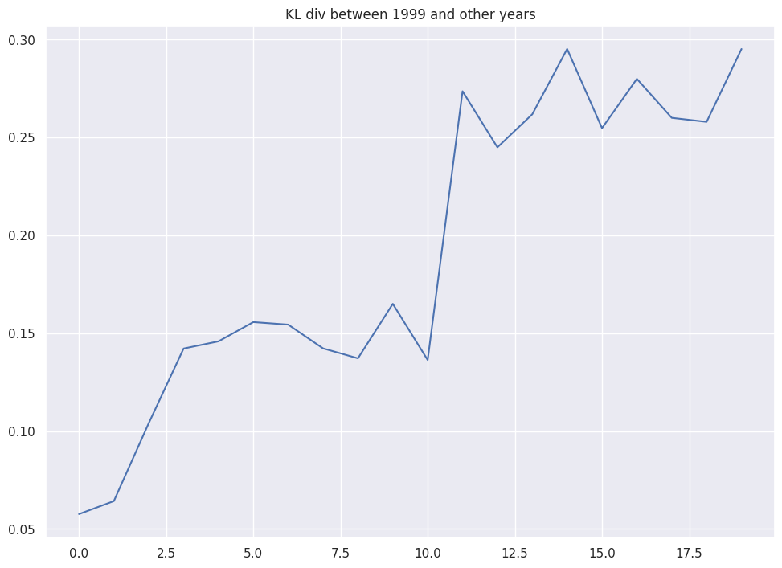

```python
plt.plot(divs)
plt.title("KL div between 1999 and other years")
plt.show()
```

Видим, что расстояние между 1999 годом и остальными годами заметно растет со временем

## Population stability index

```python
for year in range(2000, 2020):
    value = psi(
        periods[year - 1999]["3PM"],
        periods[year - 1999 - 1]["3PM"])
    if value < 0.1:
        print(f"Между {year - 1} и {year} значимых различий нет")
    elif 0.1 <= value < 0.2:
        print(f"Между {year - 1} и {year} есть тенденции к изменениям, требуется наблюдение")
    else:
        print(f"Между {year - 1} и {year} значимые изменения")
```

```
Между 1999 и 2000 есть тенденции к изменениям, требуется наблюдение
Между 2000 и 2001 значимых различий нет
Между 2001 и 2002 есть тенденции к изменениям, требуется наблюдение
Между 2002 и 2003 есть тенденции к изменениям, требуется наблюдение
Между 2003 и 2004 значимых различий нет
Между 2004 и 2005 значимых различий нет
Между 2005 и 2006 значимых различий нет
Между 2006 и 2007 значимых различий нет
Между 2007 и 2008 значимых различий нет
Между 2008 и 2009 значимых различий нет
Между 2009 и 2010 значимых различий нет
Между 2010 и 2011 значимых различий нет
Между 2011 и 2012 значимых различий нет
Между 2012 и 2013 значимых различий нет
Между 2013 и 2014 значимых различий нет
Между 2014 и 2015 значимых различий нет
Между 2015 и 2016 значимых различий нет
Между 2016 и 2017 значимых различий нет
Между 2017 и 2018 значимых различий нет
Между 2018 и 2019 значимые изменения
```

```python
for year in range(2000, 2020):
    value = psi(
        periods[0]["3PM"],
        periods[year - 1999 - 1]["3PM"])
    if value < 0.1:
        print(f"Между {1999} и {year} значимых различий нет")
    elif 0.1 <= value < 0.2:
        print(f"Между {1999} и {year} есть тенденции к изменениям, требуется наблюдение")
    else:
        print(f"Между {1999} и {year} значимые изменения")
```

```
Между 1999 и 2000 значимых различий нет
Между 1999 и 2001 есть тенденции к изменениям, требуется наблюдение
Между 1999 и 2002 есть тенденции к изменениям, требуется наблюдение
Между 1999 и 2003 есть тенденции к изменениям, требуется наблюдение
Между 1999 и 2004 значимые изменения
Между 1999 и 2005 значимые изменения
Между 1999 и 2006 значимые изменения
Между 1999 и 2007 значимые изменения
Между 1999 и 2008 значимые изменения
Между 1999 и 2009 значимые изменения
Между 1999 и 2010 значимые изменения
Между 1999 и 2011 значимые изменения
Между 1999 и 2012 значимые изменения
Между 1999 и 2013 значимые изменения
Между 1999 и 2014 значимые изменения
Между 1999 и 2015 значимые изменения
Между 1999 и 2016 значимые изменения
Между 1999 и 2017 значимые изменения
Между 1999 и 2018 значимые изменения
Между 1999 и 2019 значимые изменения
```

Как и ожидалось, между 1999 годом и остальными обнаружены сильные различия

## Data Quality

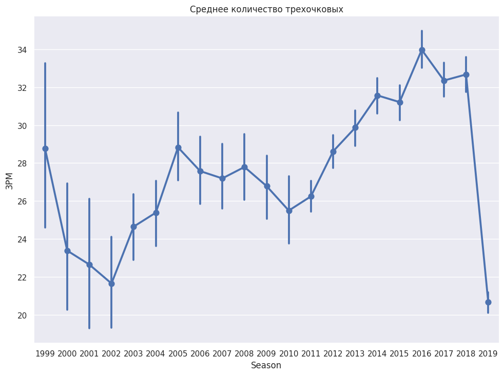

```python
sns.set(rc={'figure.figsize':(11.7,8.27)})
sns.pointplot(data=df, x="Season", y="3PM")\
.set_title("Среднее количество трехочковых")
plt.show()
```

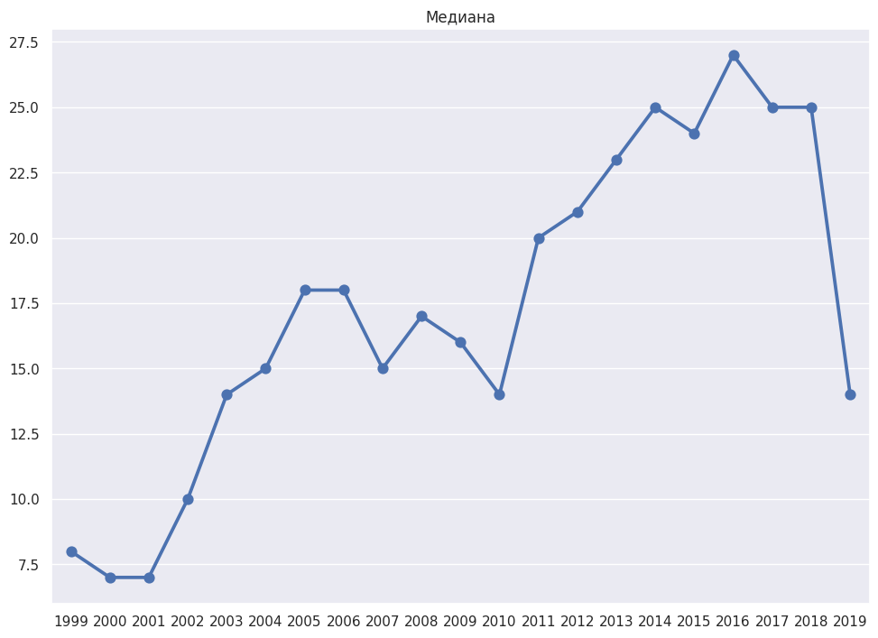

```python
sns.set(rc={'figure.figsize':(11.7,8.27)})
sns.pointplot(x=[i for i in range(1999, 2020)],
              y=[periods[i]["3PM"].median() for i in range(21)])\
.set_title("Медиана")
plt.show()
```

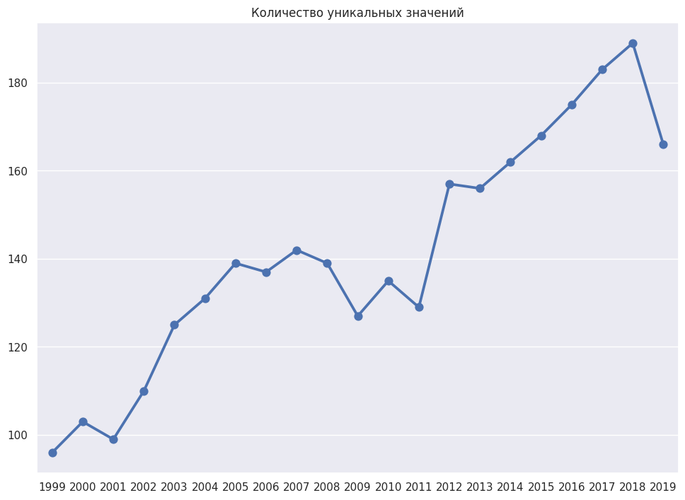

```python
sns.set(rc={'figure.figsize':(11.7,8.27)})
sns.pointplot(x=[i for i in range(1999, 2020)],
              y=[periods[i]["3PM"].nunique() for i in range(21)])\
.set_title("Количество уникальных значений")
plt.show()
```

Видим, что изменения медианы, количества уникальных значений и среднего похожи.